# Neural Net Package Examples

Raphael Cobe

12/2018

```r
library("neuralnet")
```

Going to create a neural network to perform square rooting Type ?neuralnet for more information on the neuralnet library

Generate 50 random numbers uniformly distributed between 0 and 100 And store them as a dataframe

```r
traininginput <-  as.data.frame(runif(50, min=0, max=100))
trainingoutput <- sqrt(traininginput)
```

Column bind the data into one variable

```r
trainingdata <- cbind(traininginput,trainingoutput)
colnames(trainingdata) <- c("Input","Output")
```

```r
net.sqrt <- neuralnet(Output~Input,trainingdata, hidden=10, threshold=0.01)
print(net.sqrt)
```

```
## $call
## neuralnet(formula = Output ~ Input, data = trainingdata, hidden = 10,
##     threshold = 0.01)
##
## $response
##       Output
## 1  7.5639798
## 2  8.5295378
## 3  6.9345254
## 4  9.5555103
## 5  5.8251806
## 6  7.4768080
## 7  5.8186055
## 8  9.8124237
## 9  5.1412549
```

[output cut: 383 more lines]

Plot the neural network

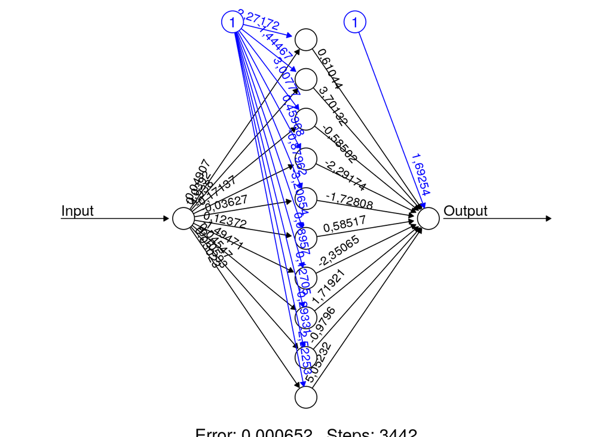

```r
plot(net.sqrt, rep = "best")
```

```r
dev.off()
```

```r
testdata <- as.data.frame((1:10)^2) #Generate some squared numbers
net.results <- compute(net.sqrt, testdata) #Run them through the neural network
```

```r
ls(net.results)
```

```
## [1] "net.result" "neurons"
```

Lets see the results

```r
print(net.results$net.result)
```

```
##           [,1]
##  [1,] 1,072512
##  [2,] 2,096253
##  [3,] 2,997402
##  [4,] 4,003830
##  [5,] 4,995046
##  [6,] 6,004305
##  [7,] 6,999059
##  [8,] 7,995864
##  [9,] 9,007463
## [10,] 9,976953
```

Lets display a better version of the results

```r
cleanoutput <- cbind(testdata,sqrt(testdata),
                     as.data.frame(net.results$net.result))
colnames(cleanoutput) <- c("Input","Expected Output","Neural Net Output")
print(cleanoutput)
```

```
##    Input Expected Output Neural Net Output
## 1      1               1          1,072512
## 2      4               2          2,096253
## 3      9               3          2,997402
## 4     16               4          4,003830
## 5     25               5          4,995046
## 6     36               6          6,004305
## 7     49               7          6,999059
## 8     64               8          7,995864
## 9     81               9          9,007463
## 10   100              10          9,976953
```

# `sin` function

Generate random data and the dependent variable

```r
x <- sort(runif(50, min = 0, max = 4*pi))
y <- sin(x)

data <- cbind(x,y)
```

Create the neural network responsible for the sin function

```r
library(neuralnet)
sin.nn <- neuralnet(y ~ x, data = data, hidden = 5, stepmax = 100000, learningrate = 10e-6,
                    act.fct = 'logistic', err.fct = 'sse', linear.output = T)
```

Visualize the neural network

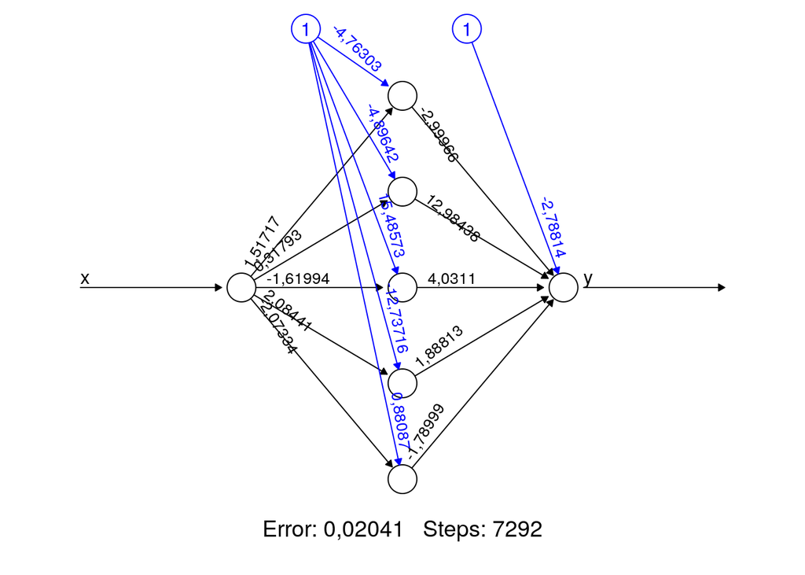

```r
plot(sin.nn, rep="best")
```

```r
dev.off()
```

Generate data for the prediction of the using the neural net;

```r
testdata<- as.data.frame(runif(10, min=0, max=(4*pi)))
testdata
```

```
##    runif(10, min = 0, max = (4 * pi))
## 1                            5,463631
## 2                            6,171670
## 3                            5,958691
## 4                           10,418360
## 5                            3,378042
## 6                            2,041453
## 7                            0,403054
## 8                            2,959871
## 9                            6,503839
## 10                           6,332437
```

Calculate the real value using the `sin` function

```r
testdata.result <- sin(testdata)
```

Make the prediction

```r
sin.nn.result <- compute(sin.nn, testdata)
sin.nn.result$net.result
```

```
##              [,1]
##  [1,] -0,75845396
##  [2,] -0,08397267
##  [3,] -0,31704182
##  [4,] -0,88679419
##  [5,] -0,24526311
##  [6,]  0,88893526
##  [7,]  0,39063449
##  [8,]  0,18341858
##  [9,]  0,26810025
## [10,]  0,09172146
```

Compare with the real values:

```r
better <- cbind(testdata, sin.nn.result$net.result, testdata.result, (sin.nn.result$net.result-testdata.result))
colnames(better) <- c("Input", "NN Result", "Result", "Error")

better
```

```
##        Input   NN Result      Result        Error
## 1   5,463631 -0,75845396 -0,73084136 -0,027612601
## 2   6,171670 -0,08397267 -0,11128406  0,027311390
## 3   5,958691 -0,31704182 -0,31882983  0,001788010
## 4  10,418360 -0,88679419 -0,83798583 -0,048808368
## 5   3,378042 -0,24526311 -0,23425231 -0,011010797
## 6   2,041453  0,88893526  0,89127089 -0,002335624
## 7   0,403054  0,39063449  0,39222947 -0,001594986
## 8   2,959871  0,18341858  0,18072274  0,002695838
## 9   6,503839  0,26810025  0,21886750  0,049232744
## 10  6,332437  0,09172146  0,04923159  0,042489873
```

Calculate the RMSE:

```r
library(Metrics)
rmse(better$Result, better$`NN Result`)
```

[output not shown]

Plot the results:

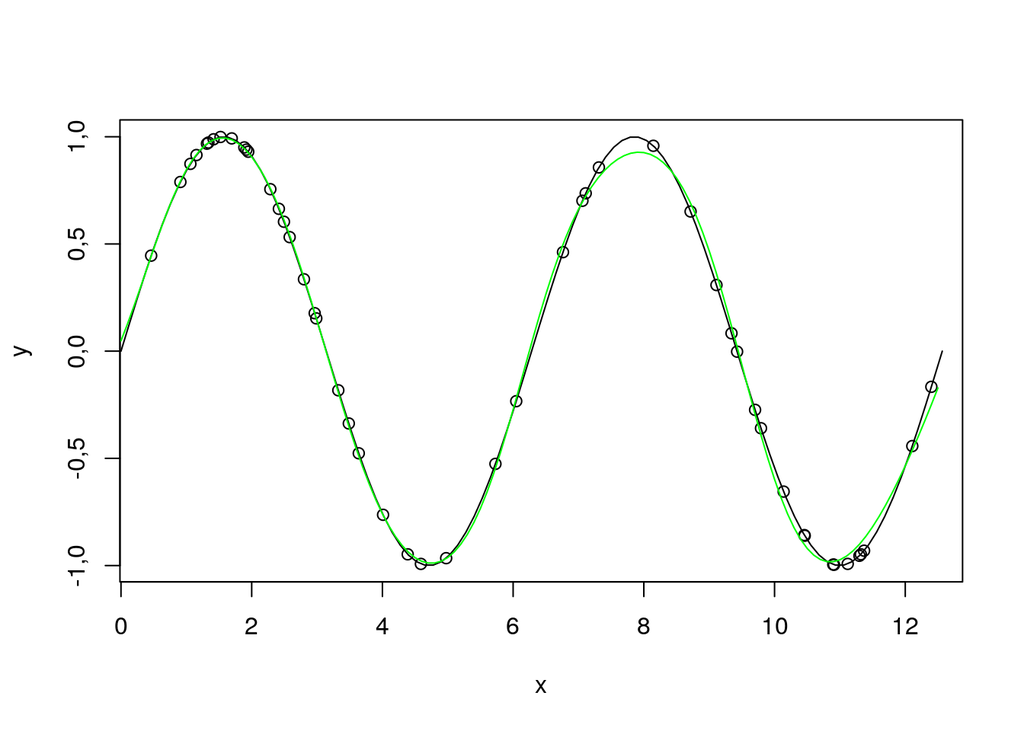

```r
plot(x,y)
plot(sin, 0, (4*pi), add=T)
x1 <- seq(0, 4*pi, by=0.1)
lines(x1, compute(sin.nn, data.frame(x=x1))$net.result, col="green")
```

# A classification problem

Using the `mtcars` dataset:

```r
data(mtcars)
mtcars.data <- mtcars
```

Check what is inside the dataset:

```r
head(mtcars.data)
```

```
##                    mpg cyl disp  hp drat    wt  qsec vs am gear carb
## Mazda RX4         21,0   6  160 110 3,90 2,620 16,46  0  1    4    4
## Mazda RX4 Wag     21,0   6  160 110 3,90 2,875 17,02  0  1    4    4
## Datsun 710        22,8   4  108  93 3,85 2,320 18,61  1  1    4    1
## Hornet 4 Drive    21,4   6  258 110 3,08 3,215 19,44  1  0    3    1
## Hornet Sportabout 18,7   8  360 175 3,15 3,440 17,02  0  0    3    2
## Valiant           18,1   6  225 105 2,76 3,460 20,22  1  0    3    1
```

Change the dataset so we are able to predict classes:

```r
mtcars.data$automatic <- mtcars.data$am=="1"
mtcars.data$manual <- mtcars.data$am=="0"
```

Separate into train and test data:

```r
train <- sample(x = nrow(mtcars.data), size = nrow(mtcars.data)*0.7)
train
```

```
##  [1] 17 23 20  2 25 21  9 19 12  6 32 24  4 30 26 18  3 16 11  8 15 22
```

```r
mtcars.train <- mtcars.data[train,]
mtcars.valid <- mtcars.data[-train,]
print(nrow(mtcars.train))
```

```
## [1] 22
```

```r
print(nrow(mtcars.valid))
```

```
## [1] 10
```

Build the Neural Network for the classification:

```r
nn <- neuralnet(automatic+manual ~ mpg + disp, data=mtcars.train, hidden = 3,
                err.fct = "ce", linear.output = F, lifesign = "minimal", stepmax = 1000000)
```

```
## hidden: 3    thresh: 0,01    rep: 1/1    steps:   47204  error: 11,00974 time: 7,35 secs
```

Let’s check the neural network that we just built

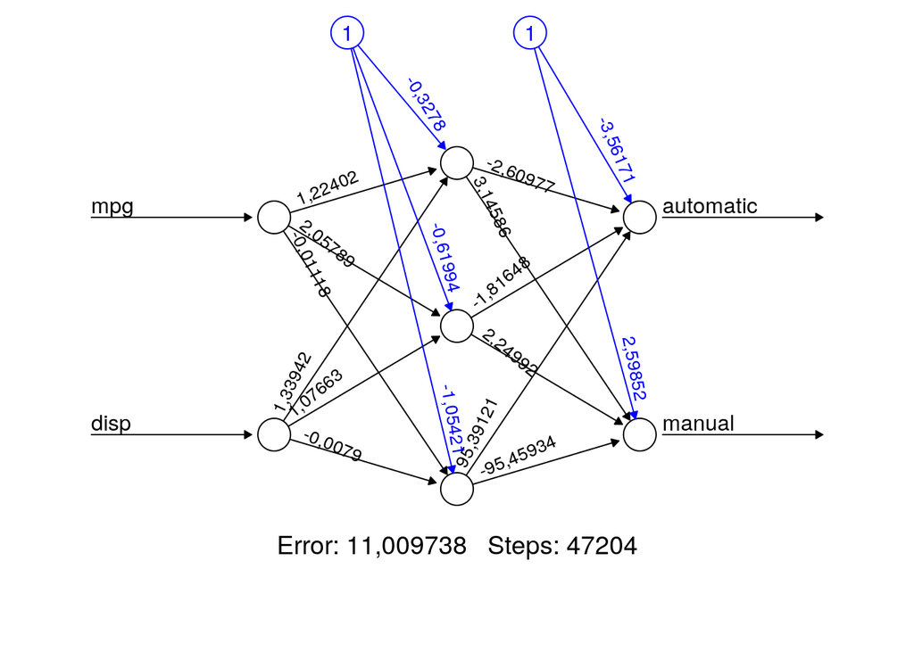

```r
plot(nn, rep = "best")
```

Let’s try to make the prediction:

```r
comp <- compute(nn, mtcars.valid[,c(1,3)])
pred.weights <- comp$net.result
idx <- apply(pred.weights, 1, which.max)
table(idx, mtcars.valid$am)
```

```
##
## idx 0 1
##   1 0 2
##   2 5 3
```

## The Challenge

Using the `iris` dataset

```r
data(iris)
iris.dataset <- iris
```

Check what is inside the dataset:

```r
head(iris.dataset)
```

```
##   Sepal.Length Sepal.Width Petal.Length Petal.Width Species
## 1          5,1         3,5          1,4         0,2  setosa
## 2          4,9         3,0          1,4         0,2  setosa
## 3          4,7         3,2          1,3         0,2  setosa
## 4          4,6         3,1          1,5         0,2  setosa
## 5          5,0         3,6          1,4         0,2  setosa
## 6          5,4         3,9          1,7         0,4  setosa
```

Change the dataset so we are able to predict classes:

```r
iris.dataset$setosa <- iris.dataset$Species=="setosa"
iris.dataset$virginica = iris.dataset$Species == "virginica"
iris.dataset$versicolor = iris.dataset$Species == "versicolor"
```

Separate into train and test data:

```r
train <- sample(x = nrow(iris.dataset), size = nrow(iris)*0.5)
train
```

```
##  [1]  34  14  39  91  71  36 142  86  35  95 102  73  29  23  74  15  12
## [18] 132 129  62 146  52  51  27  66  54  38  96 130  32 112  49  57  81
## [35] 114  55  40 101 126 137 143  13  42  70 135  85  72  98 134 119  68
## [52]  92  76  99 138  80  33 125  67 104 133  63  48  31 116  41 109  25
## [69]  64 140   5  69  18  37 120
```

```r
iristrain <- iris.dataset[train,]
irisvalid <- iris.dataset[-train,]
print(nrow(iristrain))
```

```
## [1] 75
```

```r
print(nrow(irisvalid))
```

```
## [1] 75
```

Build the Neural Network for the classification:

```r
nn <- neuralnet(setosa+versicolor+virginica ~ Sepal.Length + Sepal.Width, data=iristrain, hidden=3,
                err.fct = "ce", linear.output = F, lifesign = "minimal", stepmax = 1000000)
```

```
## hidden: 3    thresh: 0,01    rep: 1/1    steps:   67561  error: 54,50644 time: 13,97 secs
```

```r
# plot(nn, rep="best")
```

Let’s try to make the prediction:

```r
comp <- compute(nn, irisvalid[-3:-8])
pred.weights <- comp$net.result
idx <- apply(pred.weights, 1, which.max)
pred <- c('setosa', 'versicolor', 'virginica')[idx]
table(pred, irisvalid$Species)
```

```
##
## pred         setosa versicolor virginica
##   setosa         26          0         0
##   versicolor      0         15         8
##   virginica       0          7        19
```

# AND operation

```r
AND <- c(rep(0,3),1)
OR <- c(0,rep(1,3))
binary.data <- data.frame(expand.grid(c(0,1), c(0,1)), AND)
print(net <- neuralnet(AND~Var1+Var2, binary.data, hidden=0, rep=10, err.fct="ce", linear.output=FALSE))
```

```
## $call
## neuralnet(formula = AND ~ Var1 + Var2, data = binary.data, hidden = 0,
##     rep = 10, err.fct = "ce", linear.output = FALSE)
##
## $response
##   AND
## 1   0
## 2   0
## 3   0
## 4   1
##
## $covariate
##      Var1 Var2
## [1,]    0    0
## [2,]    1    0
## [3,]    0    1
## [4,]    1    1
##
## $model.list
## $model.list$response
## [1] "AND"
##
## $model.list$variables
## [1] "Var1" "Var2"
##
##
## $err.fct
## function (x, y)
## {
##     -(y * log(x) + (1 - y) * log(1 - x))
## }
## <bytecode: 0x563df3f21a98>
## <environment: 0x563df8b738b0>
## attr(,"type")
## [1] "ce"
##
## $act.fct
## function (x)
## {
##     1/(1 + exp(-x))
```

[output cut: 337 more lines]

```
## reached.threshold   0,008658477   0,008887224   0,009507369   0,008955565
## steps             133,000000000 148,000000000 118,000000000 133,000000000
## Intercept.to.AND  -12,611361463 -12,906708899 -12,239903957 -13,055785044
## Var1.to.AND         8,309361661   8,489631153   8,086739043   8,633903679
## Var2.to.AND         8,302552311   8,552991888   8,021152692   8,626837025
##                            [,9]         [,10]
## error               0,055952312   0,065800799
## reached.threshold   0,008471443   0,009596354
## steps             124,000000000 117,000000000
## Intercept.to.AND  -11,982087414 -11,488441786
## Var1.to.AND         7,833572392   7,518564993
## Var2.to.AND         7,853330325   7,514945812
##
## attr(,"class")
## [1] "nn"
```

Now to validate the predictions:

```r
input <- data.frame(expand.grid(c(0,1), c(0,1)))
net.results <- compute(net, input)
cbind(round(net.results$net.result), AND)
```

```
##        AND
## [1,] 0   0
## [2,] 0   0
## [3,] 0   0
## [4,] 1   1
```